# AIML MODULE PROJECT - Applied Statistics

## Part C - 15 Marks

• DOMAIN: Startup ecosystem • CONTEXT: Company X is a EU online publisher focusing on the startups industry. The company specifically reports on the business related to technology news, analysis of emerging trends and profiling of new tech businesses and products. Their event i.e. Startup Battlefield is the world’s pre-eminent startup competition. Startup Battlefield features 15-30 top early stage startups pitching top judges in front of a vast live audience, present in person and online. • DATA DESCRIPTION: CompanyX_EU.csv - Each row in the dataset is a Start-up company and the columns describe the company. • DATA DICTIONARY:

1. Startup: Name of the company
2. Product: Actual product
3. Funding: Funds raised by the company in USD
4. Event: The event the company participated in
5. Result: Described by Contestant, Finalist, Audience choice, Winner or Runner up
6. OperatingState: Current status of the company, Operating ,Closed, Acquired or IPO *Dataset has been downloaded from the internet. All the credit for the dataset goes to the original creator of the data. • PROJECT OBJECTIVE: Analyse the data of the various companies from the given dataset and perform the tasks that are specified in the below steps. Draw insights from the various attributes that are present in the dataset, plot distributions, state hypotheses and draw conclusions from the dataset.

STEPS AND TASK [15 Marks]:

1. Read the CSV file.
2. Data Exploration: [1 Mark]

   A. Check the datatypes of each attribute.

   B. Check for null values in the attributes
3. Data preprocessing & visualisation: [4 Marks]

   A. Drop the null values. [1 Mark]

   B. Convert the ‘Funding’ features to a numerical value.

   (Execute below code)

   df1.loc[:,'Funds_in_million'] = df1['Funding'].apply(lambda x: float(x[1:-1])/1000 if x[-1] == 'K' else (float(x[1:-1])*1000 if x[-1] == 'B' else float(x[1:-1])))

   C. Plot box plot for funds in million. [1 Mark]

   D. Check the number of outliers greater than the upper fence. [1 Mark]

   E. Check frequency of the OperatingState features classes. [1 Mark]
4. Statistical Analysis: [10 Marks]

A. Is there any significant difference between Funds raised by companies that are still operating vs companies that closed down? [1 Mark]

B. Write the null hypothesis and alternative hypothesis. [1 Mark]

C. Test for significance and conclusion [1 Mark]

D. Make a copy of the original data frame. [1 Mark]

E. Check frequency distribution of Result variables. [1 Mark]

F. Calculate percentage of winners that are still operating and percentage of contestants that are still operating [1 Mark]

G. Write your hypothesis comparing the proportion of companies that are operating between winners and contestants: [2 Mark]

H. Test for significance and conclusion [1 Mark]

I. Select only the Event that has ‘disrupt’ keyword from 2013 onwards. [1 Mark]

```python
df1=pd.read_csv('DS+-+Part3+-+CompanyX_EU.csv')
df1.head(20)
```

|  | Startup | Product | Funding | Event | Result | OperatingState |
| --- | --- | --- | --- | --- | --- | --- |
| 0 | 2600Hz | 2600hz.com | NaN | Disrupt SF 2013 | Contestant | Operating |
| 1 | 3DLT | 3dlt.com | $630K | Disrupt NYC 2013 | Contestant | Closed |
| 2 | 3DPrinterOS | 3dprinteros.com | NaN | Disrupt SF 2016 | Contestant | Operating |
| 3 | 3Dprintler | 3dprintler.com | $1M | Disrupt NY 2016 | Audience choice | Operating |
| 4 | 42 Technologies | 42technologies.com | NaN | Disrupt NYC 2013 | Contestant | Operating |
| 5 | 5to1 | 5to1.com | $19.3M | TC50 2009 | Contestant | Acquired |
| 6 | 8 Securities | 8securities.com | $29M | Disrupt Beijing 2011 | Finalist | Operating |
| 7 | 8020 Media | 8020media.com | NaN | TC40 2007 | Contestant | Operating |
| 8 | About Last Night | aboutlastnight.net | NaN | Disrupt NYC 2012 | Contestant | Operating |
| 9 | Adgregate Markets | adgregate.com | NaN | TC50 2008 | Contestant | Operating |
| 10 | AdhereTech | adheretech.com | $1.8M | Hardware Battlefield 2014 | Contestant | Operating |
| 11 | AdRocket | adrocket.com | $1M | TC50 2008 | Contestant | Closed |
| 12 | Affective Interfaces | affectiveinterfaces.com | NaN | TC50 2009 | Contestant | Operating |
| 13 | Agrilyst | agrilyst.com | $1M | Disrupt SF 2015 | Winner | Operating |
| 14 | Aiden | aiden.ai | $750K | Disrupt London 2016 | Contestant | Operating |
| 15 | AirBoxLab | foobot.io | $17.9K | Hardware Battlefield 2014 | Contestant | Operating |
| 16 | Aircall | aircall.io | $11.6M | Disrupt SF 2015 | Contestant | Operating |
| 17 | AirDroids | airdroids.com | $929.2K | Hardware Battlefield 2014 | Contestant | Closed |
| 18 | AirHelp | airhelp.com | $12.2M | Disrupt NYC 2014 | Contestant | Operating |
| 19 | AirWander | airwander.com | NaN | Disrupt London 2016 | Contestant | Operating |

```python
df1.info()
```

```
<class 'pandas.core.frame.DataFrame'>
RangeIndex: 662 entries, 0 to 661
Data columns (total 6 columns):
 #   Column          Non-Null Count  Dtype
---  ------          --------------  -----
 0   Startup         662 non-null    object
 1   Product         656 non-null    object
 2   Funding         448 non-null    object
 3   Event           662 non-null    object
 4   Result          662 non-null    object
 5   OperatingState  662 non-null    object
dtypes: object(6)
memory usage: 31.2+ KB
```

```python
# Observations:
# 1. Funding column seems to have more null values
# 2. Funding column looks to have object datatype which can be turned to numerical
# 3. Funding column needs to be converted to the same scale
# 4. Product column also has some null values but very limited
```

```python
# A. Check the datatypes of each attribute.
df1.dtypes
```

```
Startup           object
Product           object
Funding           object
Event             object
Result            object
OperatingState    object
dtype: object
```

```python
# B. Check for null values in the attributes.
df1['Funding'].isnull().sum()
```

```
214
```

```python
df1['Product'].isnull().sum()
```

```
6
```

```python
df1.isna().sum()
```

```
Startup             0
Product             6
Funding           214
Event               0
Result              0
OperatingState      0
dtype: int64
```

```python
# 3. Data preprocessing & visualisation: [4 Marks]

# A. Drop the null values. [1 Mark]

df2=df1.dropna()
df2.isna().sum()
```

```
Startup           0
Product           0
Funding           0
Event             0
Result            0
OperatingState    0
dtype: int64
```

```python
df2.info()
```

```
<class 'pandas.core.frame.DataFrame'>
Int64Index: 446 entries, 1 to 661
Data columns (total 6 columns):
 #   Column          Non-Null Count  Dtype
---  ------          --------------  -----
 0   Startup         446 non-null    object
 1   Product         446 non-null    object
 2   Funding         446 non-null    object
 3   Event           446 non-null    object
 4   Result          446 non-null    object
 5   OperatingState  446 non-null    object
dtypes: object(6)
memory usage: 24.4+ KB
```

```python
# B. Convert the ‘Funding’ features to a numerical value.

df2.loc[:,'Funds_in_million'] = df2['Funding'].apply(lambda x: float(x[1:-1])/1000 if x[-1] == 'K' else (float(x[1:-1])*1000 if x[-1] == 'B' else float(x[1:-1])))
df2
```

|  | Startup | Product | Funding | Event | Result | OperatingState | Funds_in_million |
| --- | --- | --- | --- | --- | --- | --- | --- |
| 1 | 3DLT | 3dlt.com | $630K | Disrupt NYC 2013 | Contestant | Closed | 0.63 |
| 3 | 3Dprintler | 3dprintler.com | $1M | Disrupt NY 2016 | Audience choice | Operating | 1.00 |
| 5 | 5to1 | 5to1.com | $19.3M | TC50 2009 | Contestant | Acquired | 19.30 |
| 6 | 8 Securities | 8securities.com | $29M | Disrupt Beijing 2011 | Finalist | Operating | 29.00 |
| 10 | AdhereTech | adheretech.com | $1.8M | Hardware Battlefield 2014 | Contestant | Operating | 1.80 |
| ... | ... | ... | ... | ... | ... | ... | ... |
| 657 | Zivity | zivity.com | $8M | TC40 2007 | Contestant | Operating | 8.00 |
| 658 | Zmorph | zmorph3d.com | $1M | - | Audience choice | Operating | 1.00 |
| 659 | Zocdoc | zocdoc.com | $223M | TC40 2007 | Contestant | Operating | 223.00 |
| 660 | Zula | zulaapp.com | $3.4M | Disrupt SF 2013 | Audience choice | Operating | 3.40 |
| 661 | Zumper | zumper.com | $31.5M | Disrupt SF 2012 | Finalist | Operating | 31.50 |

446 rows × 7 columns

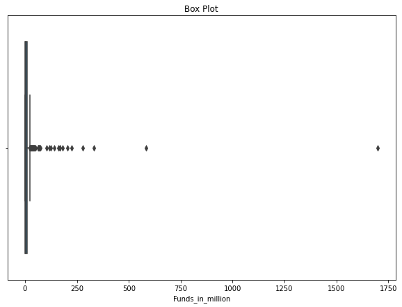

```python
# C. Plot box plot for funds in million. [1 Mark]

import seaborn as sns
import matplotlib.pyplot as plt
%matplotlib inline

fig = plt.figure(figsize =(10, 7))

Boxplot = sns.boxplot(df2.Funds_in_million).set(title='Box Plot')
```

```python
# D. Check the number of outliers greater than the upper fence. [1 Mark]

# finding the 1st quartile
q1 = np.quantile(df2.Funds_in_million, 0.25)
print('First Quartile Q1 : %1.5f' %q1)


# finding the 3rd quartile
q3 = np.quantile(df2.Funds_in_million, 0.75)
print('Third Quartile Q3 : %1.5f' %q3)

# finding the median Q2
med = np.median(df2.Funds_in_million)
print('Second Quartile Q2 : %1.5f' %med)

# finding the iqr region
iqr = q3-q1
print('IQR Region : %1.5f' %iqr)

# finding upper and lower whiskers
upper_bound = q3+(1.5*iqr)
lower_bound = q1-(1.5*iqr)
print('Upper Fence : %1.5f' %upper_bound)
print('Lower Fence : %1.5f' %lower_bound)


NumberofOutliers=len(df2[df2.Funds_in_million > upper_bound])
print('Number of outliers greater than upper fence: %1.5f' %NumberofOutliers)
```

```
First Quartile Q1 : 0.74525
Third Quartile Q3 : 9.47500
Second Quartile Q2 : 2.20000
IQR Region : 8.72975
Upper Fence : 22.56962
Lower Fence : -12.34937
Number of outliers greater than upper fence: 60.00000
```

```python
# Lets delete the outlier records
df3=df2.drop(df2[df2.Funds_in_million > upper_bound].index)
df3.info()
df3
```

```
<class 'pandas.core.frame.DataFrame'>
Int64Index: 386 entries, 1 to 660
Data columns (total 7 columns):
 #   Column            Non-Null Count  Dtype
---  ------            --------------  -----
 0   Startup           386 non-null    object
 1   Product           386 non-null    object
 2   Funding           386 non-null    object
 3   Event             386 non-null    object
 4   Result            386 non-null    object
 5   OperatingState    386 non-null    object
 6   Funds_in_million  386 non-null    float64
dtypes: float64(1), object(6)
memory usage: 24.1+ KB
```

|  | Startup | Product | Funding | Event | Result | OperatingState | Funds_in_million |
| --- | --- | --- | --- | --- | --- | --- | --- |
| 1 | 3DLT | 3dlt.com | $630K | Disrupt NYC 2013 | Contestant | Closed | 0.63 |
| 3 | 3Dprintler | 3dprintler.com | $1M | Disrupt NY 2016 | Audience choice | Operating | 1.00 |
| 5 | 5to1 | 5to1.com | $19.3M | TC50 2009 | Contestant | Acquired | 19.30 |
| 10 | AdhereTech | adheretech.com | $1.8M | Hardware Battlefield 2014 | Contestant | Operating | 1.80 |
| 11 | AdRocket | adrocket.com | $1M | TC50 2008 | Contestant | Closed | 1.00 |
| ... | ... | ... | ... | ... | ... | ... | ... |
| 645 | Yap | yapme.com | $10M | TC40 2007 | Contestant | Closed | 10.00 |
| 646 | YayPay Inc | yaypay.com | $900K | Disrupt London 2015 | Contestant | Operating | 0.90 |
| 657 | Zivity | zivity.com | $8M | TC40 2007 | Contestant | Operating | 8.00 |
| 658 | Zmorph | zmorph3d.com | $1M | - | Audience choice | Operating | 1.00 |
| 660 | Zula | zulaapp.com | $3.4M | Disrupt SF 2013 | Audience choice | Operating | 3.40 |

386 rows × 7 columns

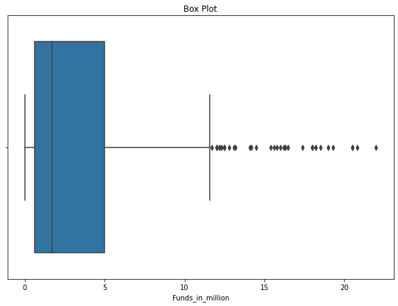

```python
fig = plt.figure(figsize =(10, 7))

Boxplot = sns.boxplot(df3.Funds_in_million).set(title='Box Plot')
```

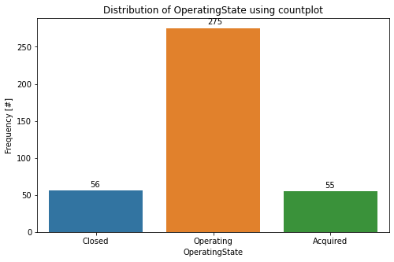

```python
# E. Check frequency of the OperatingState features classes. [1 Mark]
plt.figure(figsize=(8,5))
countplot=sns.countplot(df3.OperatingState)
plt.title('Distribution of OperatingState using countplot')
plt.xlabel('OperatingState')
plt.ylabel('Frequency [#]')
for p in countplot.patches:
        countplot.annotate('{}'.format(p.get_height()), (p.get_x()+.35, p.get_height()+5))
```

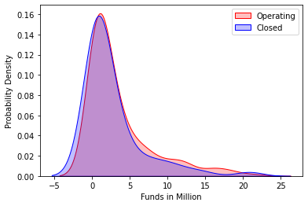

```python
# 4. Statistical Analysis: [10 Marks]

# A. Is there any significant difference between Funds raised by companies that are still operating vs companies that closed down? [1 Mark]
#plt.figure(figsize=(5,15))
fig.suptitle('Check for Fund Difference')
sns.kdeplot(df3.loc[df3.OperatingState=='Operating','Funds_in_million'],color='r', shade=True, label='Operating')
sns.kdeplot(df3.loc[df3.OperatingState=='Closed','Funds_in_million'],color='b', shade=True, label='Closed')

plt.legend(loc="upper right")
plt.xlabel('Funds in Million')
plt.ylabel('Probability Density')


# Observations
# Looks both categories of companies 'Operating' and 'Closed' are quiet similar in yelding funds
# To prove for signficant differnece in funds between them we need to use hypothesis testing
```

```python
# B. Write the null hypothesis and alternative hypothesis. [1 Mark]

#Since the number of samples is greater than 30, we will go with z-test

# Consider, Null Hypothesis (Ho):There is no significant difference in mean
#          Alternate Hypothesis (Ha): There is significant difference in mean

from statsmodels.stats.weightstats import ztest as ztest

Samplespace1=df3.loc[df3.OperatingState=='Operating','Funds_in_million']
Samplespace2=df3.loc[df3.OperatingState=='Closed','Funds_in_million']

test_statistic,p_value = ztest(Samplespace1, Samplespace2)

alpha=0.05 #Level of Significance 5%

print('P value: %1.5f' %p_value)

if p_value<alpha:
    print('Reject Null Hypothesis, which means the difference is significant')
else:
    print('Fail to reject Null Hypothesis, which means the difference is not significant')
```

```
P value: 0.19226
Fail to reject Null Hypothesis, which means the difference is not significant
```

```python
# C. Test for significance and conclusion [1 Mark]

# From the above test, we could conclude that there is no evidence to prove that,
# the companies that are operating are more successful in yielding funds than the companies that are closed.
```

```python
# D. Make a copy of the original data frame. [1 Mark]
df1Copy = df1.copy()
df1Copy.info()
```

```
<class 'pandas.core.frame.DataFrame'>
RangeIndex: 662 entries, 0 to 661
Data columns (total 6 columns):
 #   Column          Non-Null Count  Dtype
---  ------          --------------  -----
 0   Startup         662 non-null    object
 1   Product         656 non-null    object
 2   Funding         448 non-null    object
 3   Event           662 non-null    object
 4   Result          662 non-null    object
 5   OperatingState  662 non-null    object
dtypes: object(6)
memory usage: 31.2+ KB
```

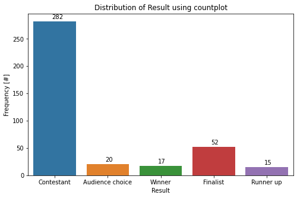

```python
# E. Check frequency distribution of Result variables. [1 Mark]

plt.figure(figsize=(8,5))
countplot=sns.countplot(df3.Result)
plt.title('Distribution of Result using countplot')
plt.xlabel('Result')
plt.ylabel('Frequency [#]')
for p in countplot.patches:
        countplot.annotate('{}'.format(p.get_height()), (p.get_x()+.35, p.get_height()+5))
```

```python
# F. Calculate percentage of winners that are still operating and percentage of contestants that are still operating [1 Mark]
Total_Winners= df3.shape[0]
print('Total_Winners: %1i' %Total_Winners)

Total_contestants= len(df3[df3.Result == 'Contestant'])
print('Total_contestants: %1i' %Total_contestants)

Operating_winners=len(df3[df3.OperatingState == 'Operating'])
print('Operating_winners: %1i' %Operating_winners)

Operating_contestants= len(df3[(df3.Result == 'Contestant') & (df3.OperatingState == 'Operating')])
print('Operating_contestants: %1i' %Operating_contestants)

Percent_operating_winners=Operating_winners/Total_Winners
Percent_of_operating_contestants=Operating_contestants/Total_contestants
print('percentage of winners that are still operating: %1.5f' %Percent_operating_winners)
print('percentage of contestants that are still operating: %1.5f' %Percent_of_operating_contestants)
```

[output not shown]

```python
# G. Write your hypothesis comparing the proportion of companies that are operating between winners and contestants: [2 Mark]

# Looks there is a slight difference, but lets prove the same using z-test for proportions

# Null Hypothesis (Ho): proportion of companies that are operating between winners and contestants are same
# Alternative Hypothesis (Ha): proportion of companies that are operating between winners and contestants are different

# corresponds to a two-tailed test, hence a z-test for two population proportions will be used.
# Rejection Region: the significance level is alpha = 0.05 , and the critical value for a two-tailed test is Zscore is+- 1.96


from statsmodels.stats.proportion import proportions_ztest

alpha=0.05 # Level of significance considered as 5%
test_statistic, p_value = proportions_ztest([Operating_contestants, Operating_winners], [Total_contestants, Total_Winners])
print('P_value: %1.5f '%p_value)


if p_value<alpha:
    print('Reject Null Hypothesis, which means the proportions are not same')
else:
    print('Fail to reject Null Hypothesis, which means the proportions are same')
```

```
P_value: 0.49421
Fail to reject Null Hypothesis, which means the proportions are same
```

```python
# H. Test for significance and conclusion [1 Mark]
# P_value(0.49421) is greater than alpha(0.05) so we fail to reject Null hypothesis

# It is concluded that the null hypothesis Ho is not rejected and
# there is not enough evidence to claim that the population proportion is different at α=0.05 significance level.
```

```python
# I. Select only the Event that has ‘disrupt’ keyword from 2013 onwards. [1 Mark]
df3.head()
df3['EventYear'] = df3['Event'].str[-4:]
df3
```

|  | Startup | Product | Funding | Event | Result | OperatingState | Funds_in_million | EventYear |
| --- | --- | --- | --- | --- | --- | --- | --- | --- |
| 1 | 3DLT | 3dlt.com | $630K | Disrupt NYC 2013 | Contestant | Closed | 0.63 | 2013 |
| 3 | 3Dprintler | 3dprintler.com | $1M | Disrupt NY 2016 | Audience choice | Operating | 1.00 | 2016 |
| 5 | 5to1 | 5to1.com | $19.3M | TC50 2009 | Contestant | Acquired | 19.30 | 2009 |
| 10 | AdhereTech | adheretech.com | $1.8M | Hardware Battlefield 2014 | Contestant | Operating | 1.80 | 2014 |
| 11 | AdRocket | adrocket.com | $1M | TC50 2008 | Contestant | Closed | 1.00 | 2008 |
| ... | ... | ... | ... | ... | ... | ... | ... | ... |
| 645 | Yap | yapme.com | $10M | TC40 2007 | Contestant | Closed | 10.00 | 2007 |
| 646 | YayPay Inc | yaypay.com | $900K | Disrupt London 2015 | Contestant | Operating | 0.90 | 2015 |
| 657 | Zivity | zivity.com | $8M | TC40 2007 | Contestant | Operating | 8.00 | 2007 |
| 658 | Zmorph | zmorph3d.com | $1M | - | Audience choice | Operating | 1.00 | - |
| 660 | Zula | zulaapp.com | $3.4M | Disrupt SF 2013 | Audience choice | Operating | 3.40 | 2013 |

386 rows × 8 columns

```python
df3.info()
```

```
<class 'pandas.core.frame.DataFrame'>
Int64Index: 386 entries, 1 to 660
Data columns (total 8 columns):
 #   Column            Non-Null Count  Dtype
---  ------            --------------  -----
 0   Startup           386 non-null    object
 1   Product           386 non-null    object
 2   Funding           386 non-null    object
 3   Event             386 non-null    object
 4   Result            386 non-null    object
 5   OperatingState    386 non-null    object
 6   Funds_in_million  386 non-null    float64
 7   EventYear         386 non-null    object
dtypes: float64(1), object(7)
memory usage: 35.2+ KB
```

```python
#Check for dummy year records
print(df3[df3.EventYear.str.contains(r'[@#&$%+-/*]')])
df3.info()
```

```
                 Startup        Product  Funding Event           Result  \
68             Bloomlife  bloomlife.com      $4M     -        Runner up
292               Knocki     knocki.com    $1.9M     -  Audience choice
416  Pillar Technologies    pillar.tech    $525K     -         Finalist
500           Siren Care     siren.care  $129.8K     -           Winner
611         Venneos GmbH    venneos.com    $1.1M     -       Contestant
658               Zmorph   zmorph3d.com      $1M     -  Audience choice

    OperatingState  Funds_in_million EventYear
68       Operating            4.0000         -
292      Operating            1.9000         -
416      Operating            0.5250         -
500      Operating            0.1298         -
611      Operating            1.1000         -
658      Operating            1.0000         -
<class 'pandas.core.frame.DataFrame'>
Int64Index: 386 entries, 1 to 660
Data columns (total 8 columns):
 #   Column            Non-Null Count  Dtype
---  ------            --------------  -----
 0   Startup           386 non-null    object
 1   Product           386 non-null    object
 2   Funding           386 non-null    object
 3   Event             386 non-null    object
 4   Result            386 non-null    object
 5   OperatingState    386 non-null    object
 6   Funds_in_million  386 non-null    float64
 7   EventYear         386 non-null    object
dtypes: float64(1), object(7)
memory usage: 35.2+ KB
```

```python
#drop the records having special characters
df4=df3.drop(df3[df3.EventYear.str.contains(r'[@#&$%+-/*]')].index)
df4.info()
```

```
<class 'pandas.core.frame.DataFrame'>
Int64Index: 380 entries, 1 to 660
Data columns (total 8 columns):
 #   Column            Non-Null Count  Dtype
---  ------            --------------  -----
 0   Startup           380 non-null    object
 1   Product           380 non-null    object
 2   Funding           380 non-null    object
 3   Event             380 non-null    object
 4   Result            380 non-null    object
 5   OperatingState    380 non-null    object
 6   Funds_in_million  380 non-null    float64
 7   EventYear         380 non-null    object
dtypes: float64(1), object(7)
memory usage: 26.7+ KB
```

```python
# Changing Event year to integer
df4['EventYear']=df4['EventYear'].astype(int)
df4.info()
```

```
<class 'pandas.core.frame.DataFrame'>
Int64Index: 380 entries, 1 to 660
Data columns (total 8 columns):
 #   Column            Non-Null Count  Dtype
---  ------            --------------  -----
 0   Startup           380 non-null    object
 1   Product           380 non-null    object
 2   Funding           380 non-null    object
 3   Event             380 non-null    object
 4   Result            380 non-null    object
 5   OperatingState    380 non-null    object
 6   Funds_in_million  380 non-null    float64
 7   EventYear         380 non-null    int32
dtypes: float64(1), int32(1), object(6)
memory usage: 25.2+ KB
```

```python
contain_disrupt = df4[(df4['Event'].astype(str).str.contains('isrupt')) & (df4.EventYear >= 2013)]
contain_disrupt.Event.value_counts()
```

```
Disrupt NY 2015        21
Disrupt NYC 2013       19
Disrupt SF 2015        19
Disrupt SF 2014        19
Disrupt SF 2013        19
Disrupt SF 2016        17
Disrupt NY 2016        16
Disrupt NYC 2014       15
Disrupt London 2015    11
Disrupt London 2016    10
Disrupt EU 2014        10
Disrupt EU 2013         9
Name: Event, dtype: int64
```